# Rise and fall of r packages

2023-05-19

## Introduction

Exploring and visualizing r packages use in the programming community based on “tags” assigned to questions in stackoverflow. This will give an insight on what might be of interest to someone who is trying to choose which areas to build skills on.

Each Stack Overflow question has a tag, which marks a question to describe its topic or technology. For instance, there’s a tag for languages like R or Python, and for packages like ggplot2 or pandas.

Data: Original source: https://data.stackexchange.com/ Downloaded from here: https://gist.github.com/dgrtwo/a30d99baa9b7bfc9f2440b355ddd1f75

A dataset with one observation for each tag in each year. The dataset includes both the number of questions asked in that tag in that year, and the total number of questions asked in that year.

```r
knitr::opts_chunk$set(message = FALSE, warning = FALSE)

library(tidyverse)
```

```r
library(dplyr)
library(stringi)
library(readxl)
library(readr)
library(ggplot2)
```

## Data

```r
setwd('~/rtdatasci_github/R/rise_and_fall/')
data <- read.csv('by_tag_year.csv')
```

## Inspect the data

```r
dim(data)
```

```
## [1] 40518     4
```

```r
str(data)
```

```
## 'data.frame':    40518 obs. of  4 variables:
##  $ year      : int  2008 2008 2008 2008 2008 2008 2008 2008 2008 2008 ...
##  $ tag       : chr  ".htaccess" ".net" ".net-2.0" ".net-3.5" ...
##  $ number    : int  54 5910 289 319 6 3 1 42 19 4 ...
##  $ year_total: int  58390 58390 58390 58390 58390 58390 58390 58390 58390 58390 ...
```

### Fraction table

This data has one observation for each pair of a tag and a year, showing the number of questions asked in that tag in that year and the total number of questions asked in that year. For instance, there were 54 questions asked about the .htaccess tag in 2008, out of a total of 58390 questions in that year.

Rather than just the counts, we’re probably interested in a percentage: the fraction of questions that year that have that tag. So let’s add that to the table.

```r
# Does the data have one observation for each pair of a tag and a year
df <- data %>% mutate(tag_year = paste0(tag, "-", year)) %>% select(tag_year, number)
if(nrow(df) == length(unique(df$tag_year))){ print("one to one relation between tag_year combination and records found")}
```

```
## [1] "one to one relation between tag_year combination and records found"
```

```r
# inspect one tag
data %>% filter(str_detect(tag, "\\.htaccess") & year=="2008")
```

```
##   year       tag number year_total
## 1 2008 .htaccess     54      58390
```

```r
# add fraction of questions per year for a tag
data_fraction <- data %>%
  mutate(fraction_of_questions = number/year_total)
```

## R status

Is it growing or sinking? Is R keeping up with other programming languages? Check if the fraction of Stack Overflow questions that are about R has been increasing or decreasing over time.

```r
# Filter for R tags
r_data <- data_fraction %>% filter(tag %in% c("r", "r-markdown"))

# Print the new table
r_data
```

```
##    year        tag number year_total fraction_of_questions
## 1  2008          r      8      58390          1.370098e-04
## 2  2009          r    524     343868          1.523841e-03
## 3  2010          r   2270     694391          3.269052e-03
## 4  2011          r   5845    1200551          4.868598e-03
## 5  2012          r  12221    1645404          7.427355e-03
## 6  2012 r-markdown     13    1645404          7.900795e-06
## 7  2013          r  22329    2060473          1.083683e-02
## 8  2013 r-markdown     73    2060473          3.542876e-05
## 9  2014          r  31011    2164701          1.432577e-02
## 10 2014 r-markdown    253    2164701          1.168753e-04
## 11 2015          r  40844    2219527          1.840212e-02
## 12 2015 r-markdown    596    2219527          2.685257e-04
## 13 2016          r  44611    2226072          2.004023e-02
## 14 2016 r-markdown    817    2226072          3.670142e-04
## 15 2017          r  54415    2305207          2.360526e-02
## 16 2017 r-markdown   1215    2305207          5.270676e-04
## 17 2018          r  28938    1085170          2.666679e-02
## 18 2018 r-markdown    629    1085170          5.796327e-04
```

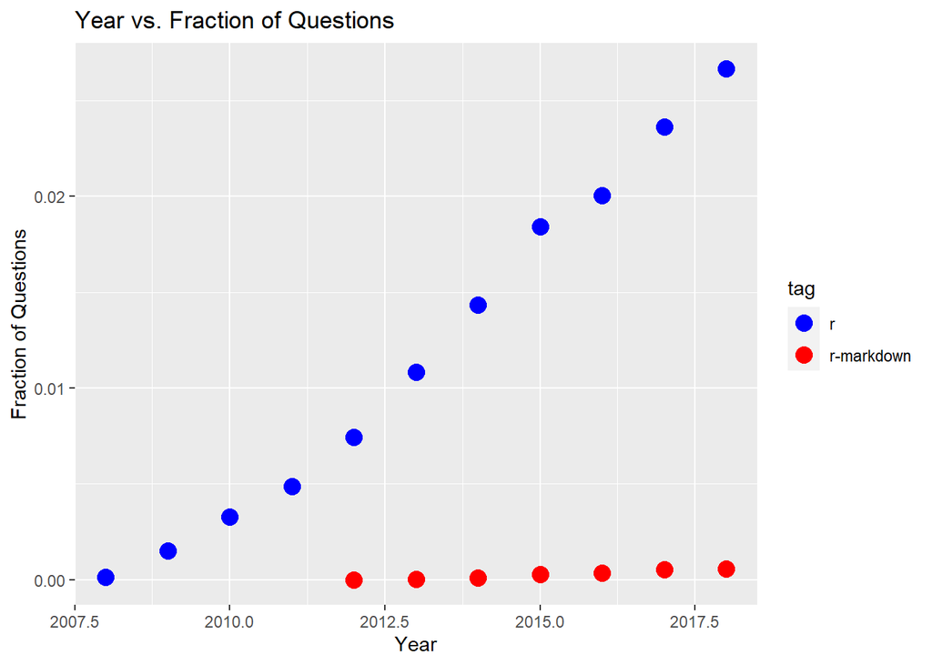

```r
# Visualize R status over time
r_data %>%
  ggplot(aes(x = year, y = fraction_of_questions,color = tag)) +
  geom_point(size=4) +
  scale_color_manual(values = c("r" = "blue", "r-markdown" = "red")) +
  labs(title = "Year vs. Fraction of Questions", x = "Year", y = "Fraction of Questions")
```

## Other r-related tags

Eg. dplyr and ggplot2. Are each of those tags increasing as a fraction of overall questions? Are any of them decreasing?

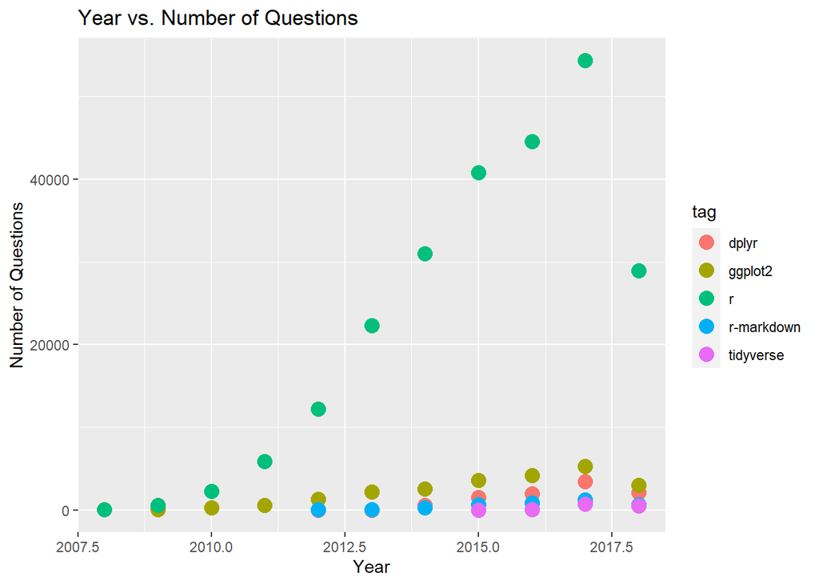

```r
tags <- c("r", "r-markdown", "dplyr", "tidyverse", "ggplot2", "tidytext")

# Filter for those tags
data_tags <- data_fraction %>% filter(tag %in% tags)

# Plot tags over time
data_tags %>%
  ggplot(aes(x = year, y = number ,color = tag)) +
  geom_point(size=4) +
  scale_color_discrete()+
  labs(title = "Year vs. Number of Questions", x = "Year", y = "Number of Questions")
```

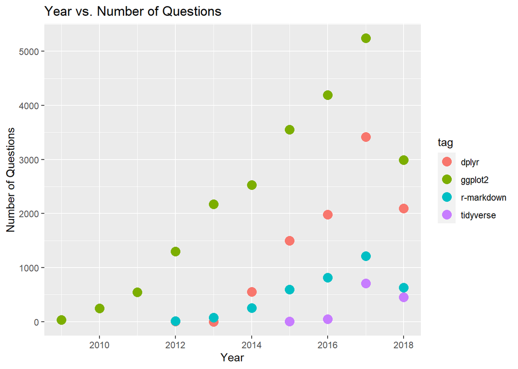

```r
# plot for R makes it harder to see individual packages, remove "r" and plot again:
data_tags %>%
  filter(!tag == "r") %>%
  ggplot(aes(x = year, y = number,color = tag)) +
  geom_point(size=4) +
  scale_color_discrete()+
  labs(title = "Year vs. Number of Questions", x = "Year", y = "Number of Questions")
```

```r
# Summary:
# ggplot2 had the highest number of quetions
# all selected r packages saw decline in questions from 2017 to 2018
```

## Comprehensive list of r-pacakges

r-packages that are in my system (source: CRAN)

```r
chooseCRANmirror(ind=1)  # Set the CRAN mirror index to 1 (or choose the appropriate index for your location)

pkg_list <- available.packages()  %>% as.data.frame()
dim(pkg_list)
```

```
## [1] 19500    17
```

```r
# since the pkg_list is too big, we will select the ones that have value in Depends to select relevant ones
pkg_list <- pkg_list %>% filter(!is.na(Depends)|Depends=="")
dim(pkg_list)
```

```
## [1] 14368    17
```

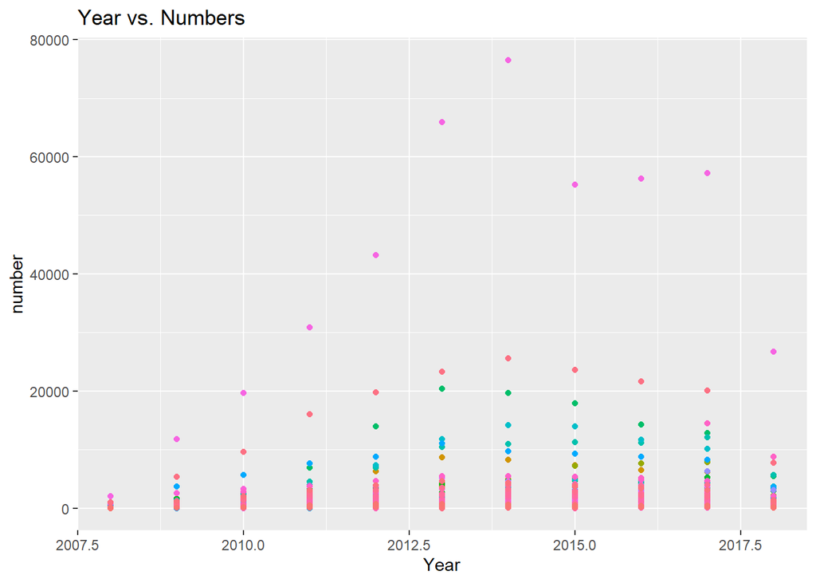

```r
# Filter for those tags
data_comprehensive_tags <- data_fraction %>% filter(tag %in% tolower(pkg_list$Package))

# plot for R makes it harder to see individual packages, remove "r" and plot again:
data_comprehensive_tags %>%
  filter(!tag == "r") %>%
  ggplot(aes(x = year, y = number,color = tag)) +
  geom_point() +
  labs(title = "Year vs. Numbers", x = "Year", y = "number")+
   # Remove the legend for the 'tag' variable because it was too overwhelming
  theme(legend.position = "none")
```

### Subset comprehensive

Plotting a really high dim dataframe wont provide usable insight, so we subet the dataset

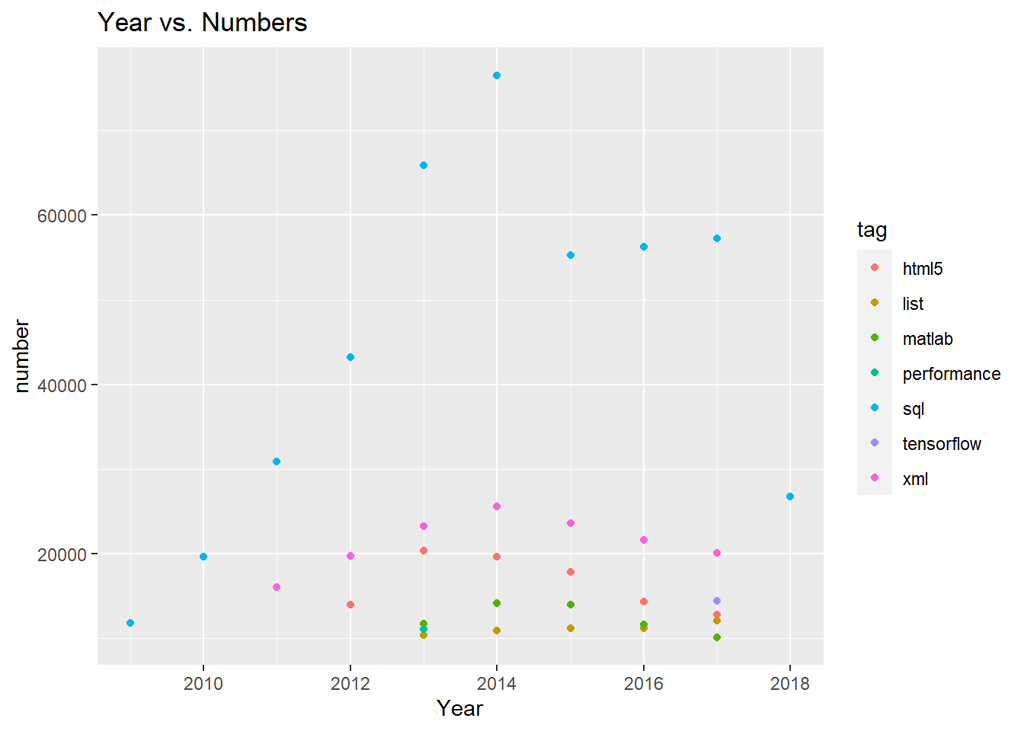

```r
# select the ones that have >10000 questions
data_comprehensive_tags %>%
  filter(!tag == "r") %>%
  filter(number > 10000) %>%
  ggplot(aes(x = year, y = number,color = tag)) +
  geom_point() +
  labs(title = "Year vs. Numbers", x = "Year", y = "number")
```

```r
## Summary
# notice that although pkg list were gathered from available.packages() that looks for rpackages, the plot shows that the top questions were packages that are non native to R
```

### Top 10

Growing:

```r
data_comprehensive_tags %>%
  group_by(tag) %>%
  summarize(total_growth = max(number) - min(number)) %>%
  arrange(desc(total_growth)) %>%
  top_n(10)
```

```
## # A tibble: 10 × 2
##    tag         total_growth
##    <chr>              <int>
##  1 sql                74509
##  2 xml                24592
##  3 html5              20363
##  4 tensorflow         14435
##  5 matlab             14086
##  6 list               11957
##  7 performance        10243
##  8 class               8513
##  9 dictionary          7783
## 10 redux               5903
```

```r
data_comprehensive_tags %>%
  group_by(tag) %>%
  summarize(total_shrinkage = min(number) - max(number)) %>%
  arrange(desc(total_shrinkage)) %>%
  top_n(10)
```

```
## # A tibble: 10 × 2
##    tag      total_shrinkage
##    <chr>              <int>
##  1 diagram             -139
##  2 monitor             -139
##  3 dbi                 -154
##  4 profiler            -155
##  5 pixels              -161
##  6 ipa                 -166
##  7 treemap             -166
##  8 folders             -168
##  9 boot                -171
## 10 shapes              -179
```

## Most asked about language

which tags have the most questions overall, not just within a particular year

```r
# total number of questions for each tag
sorted_tags <- data_fraction %>%
  group_by(tag) %>%
  summarize(total_questions =sum(number)) %>%
  arrange(desc(total_questions))



# Print the new table
head(sorted_tags,10)
```

```
## # A tibble: 10 × 2
##    tag        total_questions
##    <chr>                <int>
##  1 javascript         1632049
##  2 java               1425961
##  3 c#                 1217450
##  4 php                1204291
##  5 android            1110261
##  6 python              970768
##  7 jquery              915159
##  8 html                755341
##  9 c++                 574263
## 10 ios                 566075
```

## Summary

Insights gathered from this exercise:

```r
# ggplot2 had the highest number of questions in stackover flow between 2009 to 2018

# all selected r packages saw decline in questions from 2017 to 2018

# sql from CRAN (collected from available.packages() is the most popular package over time

# javascript has the most number of questions in stackoverflow

# where does r rank among all the tags for different programming languages,regardless of year: 21st
print(paste0("R language rank among all tags: ", which(sorted_tags$tag == 'r')))
```

```
## [1] "R language rank among all tags: 21"
```